# Chromosome 3 QTL Peak — Multi-Evidence Analysis (v3)

*Pararge aegeria* — Haplotype-level introgression mapping using phased genotypes

### 🧬 v3: Phased Haplotype Analysis

This analysis uses the **phased VCF** from the EHH Haplotype-Based Selection Analysis (SHAPEIT4 phasing). Unlike v2 (unphased diploid genotypes), v3 resolves each individual into **two separate haplotypes**, enabling:

- Haplotype-level introgression tract mapping (164 haplotypes vs 82 diploids)
- Classification of DD individuals into 0, 1, or 2 introgressed haplotypes
- More precise breakpoint localisation at haplotype boundaries
- Detection of introgressed haplotypes leaking into NN population

**Input:** 15,618 phased biallelic SNPs in chr3: 9.5–13.0 Mb (vs 25,679 unphased in v2).

### Samples Excluded

**2 sample(s) removed:** `nr59`, `nr60` (same as v2; high missingness in focal region)

## Summary

| NN samples / haplotypes | 40 / 80 |
| --- | --- |
| DD samples / haplotypes | 42 / 84 |
| Region analysed | Chr3: 9.5–13.0 Mb |
| Phased SNPs in region | 15,618 |
| SNPs <5% missing | 15,618 |

| Max −log₁₀(p) | 48.1 |
| --- | --- |
| SNPs with −log₁₀(p) > 40 | 767 |
| SNPs with −log₁₀(p) > 50 | 0 |
| DD: 2 introgressed haps | 42 / 42 |
| DD: 1 introgressed hap | 0 / 42 |

### Core Introgression Regions (≥90% DD haplotype coverage)

#1: 10.94 – 11.03 Mb

9 region(s) at ≥90% DD haplotype introgression coverage

| Rank | Coordinates | Size | Max DD hap coverage | Mean DD hap coverage |
| --- | --- | --- | --- | --- |
| 1 | 10.94 – 11.03 Mb | 90 kb | 100.0% | 100.0% |
| 2 | 9.99 – 10.05 Mb | 60 kb | 100.0% | 100.0% |
| 3 | 9.56 – 9.62 Mb | 50 kb | 100.0% | 100.0% |
| 4 | 10.54 – 10.59 Mb | 50 kb | 100.0% | 100.0% |
| 5 | 11.94 – 11.98 Mb | 50 kb | 100.0% | 100.0% |
| 6 | 12.63 – 12.69 Mb | 50 kb | 100.0% | 100.0% |
| 7 | 11.20 – 11.23 Mb | 40 kb | 100.0% | 100.0% |
| 8 | 12.20 – 12.22 Mb | 30 kb | 100.0% | 100.0% |
| 9 | 10.12 – 10.13 Mb | 20 kb | 100.0% | 100.0% |

## Approach 1: Multi-Statistic Sliding Windows

Same statistics, phased allele counts

Δ(SNP-index), F<sub>ST</sub>, and Fisher's exact test now computed from **phased haplotype allele counts** (2N alleles per group). Smoothed with 25 kb and 50 kb windows. Phasing does not change allele frequencies or population-level statistics, but ensures consistent allele counting across individuals.

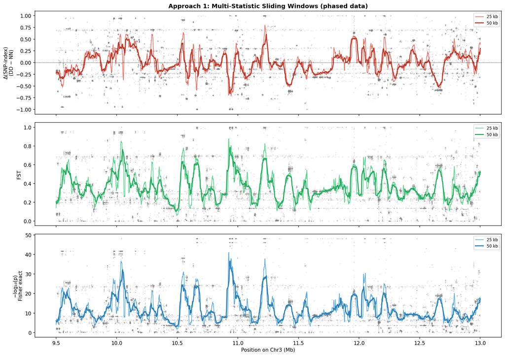

## Normalised Multi-Evidence Overlay

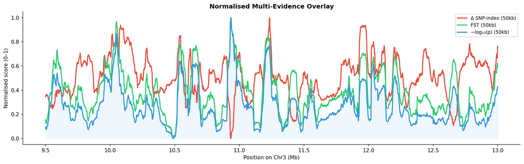

## Approach 2: Haplotype-Level Introgression Tracts NEW in v3

Key advance over v2: individual haplotype resolution

Each individual contributes **two haplotypes** (2×82 = 164 total). The NN consensus allele was determined per SNP from all 80 NN haplotypes. Per-haplotype discordance was computed in 50 kb sliding windows (10 kb step). Introgression = contiguous run of >50% discordance. This resolves heterozygous individuals into one introgressed + one non-introgressed haplotype.

### Reading the Tract Plot

Each individual is shown as **two horizontal rows** (one per phased haplotype). The plot is divided by a black line:

- **Red blocks (top half)** = DD haplotypes that are *discordant from the NN consensus* — these are the **introgressed tracts**. A red block means that haplotype carries alleles that differ from the typical NN background, indicating it derives from a different ancestral source (the introgressed lineage).
- **Blue blocks (bottom half)** = NN haplotypes that show discordance from their own consensus. In a clean system these should be mostly absent. Any blue blocks would indicate NN individuals carrying fragments of the introgressed haplotype.
- **Light pink/blue backgrounds** = the full extent of the analysed region. Where no coloured block is drawn, the haplotype matches the NN consensus (i.e., it is *not* introgressed).
- **Width of each block** = the physical extent of the introgression tract in Mb. Wider blocks indicate longer runs of introgressed DNA. The edges of each block are **recombination breakpoints** where the ancestry switches from introgressed to non-introgressed.

### Step-by-Step Algorithm

The algorithm is a simplified form of **local ancestry inference** that leverages the two-population design (NN = reference, DD = target):

**Step 1 — Build the NN consensus haplotype (reference).**  
At each SNP position, the *modal allele* across all 80 NN haplotypes is determined. For biallelic SNPs, this is equivalent to rounding the mean allele value: if >50% of NN haplotypes carry the ALT allele, the consensus is ALT; otherwise REF. This produces a single “typical NN” haplotype vector of length 15,618 SNPs.

**Step 2 — Compute per-haplotype discordance in sliding windows.**  
For every individual (NN and DD alike), each of their two phased haplotypes is compared to the NN consensus. Within a 50 kb sliding window (stepped every 10 kb), the *discordance rate* is calculated as the fraction of non-missing SNPs where the haplotype allele differs from the consensus. A discordance of 0.0 means perfect match to the NN consensus; a discordance of 1.0 means every allele differs.

**Step 3 — Call introgression tracts.**  
A haplotype is classified as *introgressed* in a given window if discordance > 0.50 (i.e., more alleles differ from the NN consensus than match it). Contiguous runs of introgressed windows are merged into **introgression tracts**, each defined by a start and end position in Mb.

**Step 4 — Compute coverage and define core regions.**  
At each window, the fraction of DD haplotypes that are introgressed is tallied. A **core introgression region** is a contiguous stretch where ≥90% of DD haplotypes are introgressed. These are the regions most likely to contain the causal variant(s).

### Code Used

The following Python code implements the haplotype-level tract mapping. The full script is `generate_v3_report.py`.

```
# === Step 1: NN consensus haplotype ===
# For each SNP, determine the modal allele across all NN haplotypes
nn_haps = hap_matrix[good_snps][:, :n_nn, :]      # shape: (n_snps, n_nn, 2)
nn_haps_flat = nn_haps.reshape(n_good, -1)          # flatten to (n_snps, n_nn*2)
nn_consensus = np.zeros(n_good)
for i in range(n_good):
    vals = nn_haps_flat[i]
    vals = vals[~np.isnan(vals)]
    if len(vals) > 0:
        nn_consensus[i] = np.round(np.mean(vals))   # mode ~ round(mean) for biallelic

# === Step 2: Sliding-window discordance per haplotype ===
win_size = 50000                                     # 50 kb windows
win_step = 10000                                     # 10 kb step
win_starts = np.arange(REGION_START, REGION_END - win_size + 1, win_step)

hap_disc = np.full((n_wins, n_all, 2), np.nan)      # discordance matrix
for wi in range(n_wins):
    ws, we = win_starts[wi], win_starts[wi] + win_size
    mask = (good_pos >= ws) & (good_pos < we)
    if np.sum(mask) < 3:
        continue
    cons = nn_consensus[mask]                        # consensus alleles in window
    for si in range(n_all):
        for hi in range(2):                       # each haplotype
            h = hap_good[mask, si, hi]
            valid = ~np.isnan(h)
            if np.sum(valid) > 0:
                hap_disc[wi, si, hi] = np.mean(h[valid] != cons[valid])

# === Step 3: Call introgression tracts ===
def find_tracts(disc_vec, threshold=0.5):
    # Find contiguous runs above threshold.
    tracts = []
    in_tract = False
    for i in range(len(disc_vec)):
        if not np.isnan(disc_vec[i]) and disc_vec[i] > threshold:
            if not in_tract:
                start_i = i
                in_tract = True
        else:
            if in_tract:
                tracts.append((start_i, i - 1))
                in_tract = False
    if in_tract:
        tracts.append((start_i, len(disc_vec) - 1))
    return tracts

# === Step 4: Coverage = fraction of DD haplotypes introgressed per window ===
dd_hap_introgressed = np.zeros(n_wins)
for wi in range(n_wins):
    count = 0
    for si in range(n_nn, n_all):             # DD samples only
        for hi in range(2):
            d = hap_disc[wi, si, hi]
            if not np.isnan(d) and d > 0.5:
                count += 1
    dd_hap_introgressed[wi] = count / (n_dd * 2)    # fraction of DD haplotypes
```

### Relationship to Published Methods

This approach is a simplified, two-population form of **local ancestry inference (LAI)**. Several established methods use conceptually similar strategies:

[output not shown]

**Introgression in Lepidoptera:** In the *Heliconius* butterfly radiation, Edelman et al. (2019, *Science*) found that introgression has been a major contributor of genealogical discordance, with 38% of loci genome-wide showing a history of introgression. Martin et al. (2019, *PLOS Biology*) showed that rates of introgression are predicted by recombination rate variation across butterfly genomes. For *Pararge aegeria* specifically, Pruisscher et al. (2018, *Molecular Ecology*) identified candidate regions for diapause induction variation including the genes *period* and *timeless*, and recent work has implicated Z-linked inheritance and repeated colonisation in shaping diapause adaptation across Scandinavian populations.

**Why this simplified approach works here:** In contrast to multi-population admixture scenarios (humans, *Heliconius*), our experimental design provides a clean two-population system where NN (non-diapause) serves as the unambiguous reference and DD (diapause) is the target population potentially carrying introgressed haplotypes. The crossing design means the ancestral population structure is known, making a simple consensus-discordance approach sufficient without requiring the full machinery of HMM-based LAI or simulation-trained neural networks. The 50% discordance threshold is conservative and biologically motivated: an introgressed haplotype should differ from the local population consensus at the majority of linked sites.

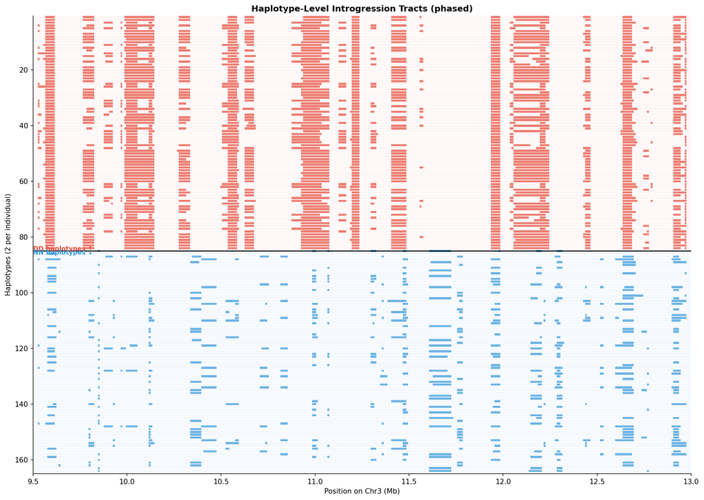

## Introgression Dosage NEW in v3

How many haplotypes carry the introgression per individual?

At the top core region (10.94–11.03 Mb), each individual is classified by how many of their two haplotypes are introgressed. **DD:** 42 homozygous (2 haps), 0 heterozygous (1 hap), 0 non-introgressed (0 haps). **NN:** 0 homozygous, 0 heterozygous, 40 non-introgressed.

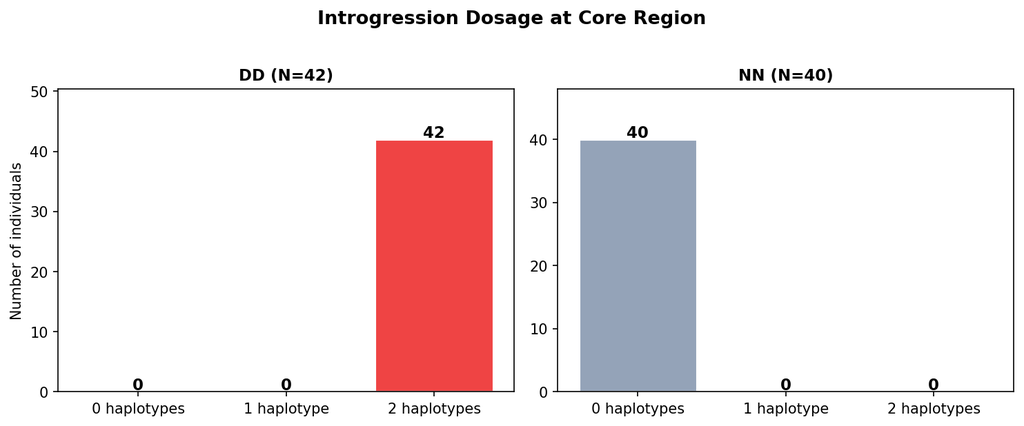

## Approach 3: Introgression Coverage & Breakpoint Density

Haplotype-level coverage (vs diploid in v2)

Coverage = fraction of DD haplotypes (out of 84) that are introgressed at each position. Core regions = contiguous segments with ≥90% coverage. Breakpoint density shows where recombination has eroded the introgression boundaries.

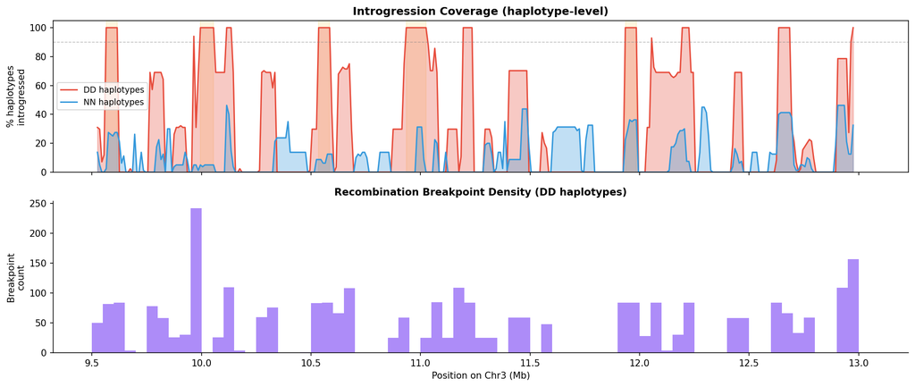

## Approach 4: Genotype Composition

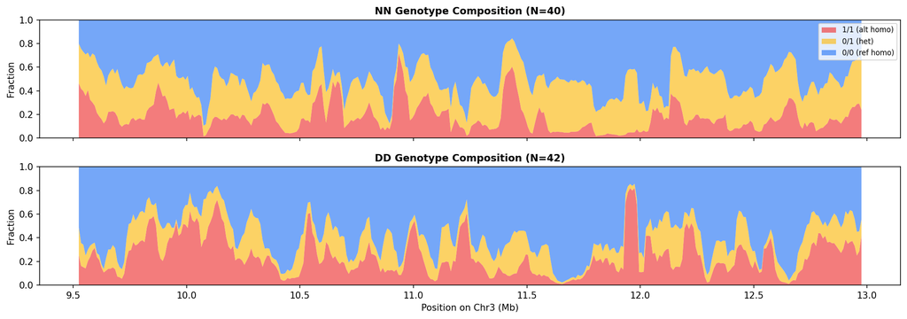

## Phased Haplotype Heatmap NEW in v3

Individual haplotypes visible (2 rows per individual)

Each individual is represented by two rows (one per haplotype). Blue = reference allele, Red = alternative allele. The phased data reveals which specific haplotype carries the introgressed block, allowing heterozygous individuals to be clearly decomposed into one NN-like and one DD-like haplotype.

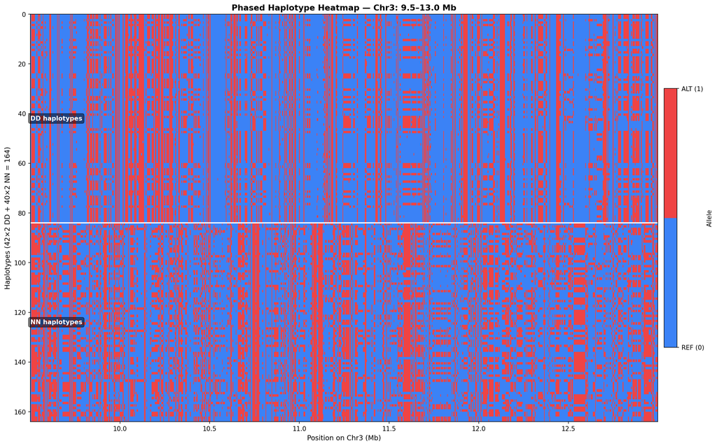

## v2 vs v3 — Core Region Comparison NEW

Impact of phasing on core region boundaries

Comparison of core introgression regions identified with unphased diploid genotypes (v2) vs phased haplotypes (v3). Differences arise because haplotype-level analysis can distinguish heterozygous carriers (1 introgressed haplotype) from homozygous carriers (2 introgressed haplotypes), providing more precise boundary resolution.

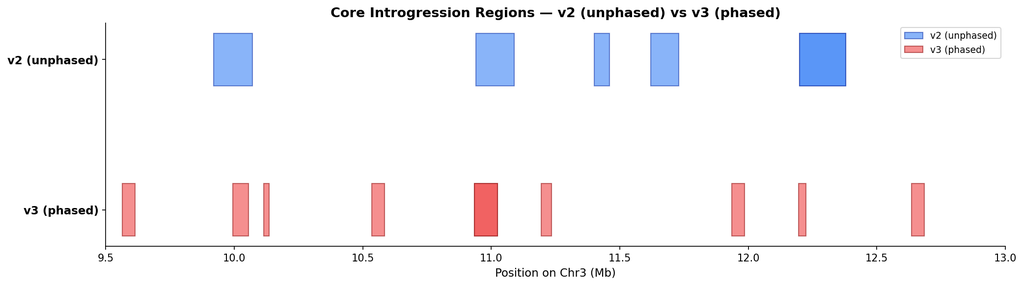

### v2 Core Regions (unphased)

| # | Coordinates | Size |
| --- | --- | --- |
| 1 | 12.20 – 12.38 Mb | 180 kb |
| 2 | 9.92 – 10.07 Mb | 150 kb |
| 3 | 10.94 – 11.09 Mb | 150 kb |
| 4 | 11.62 – 11.73 Mb | 110 kb |
| 5 | 11.40 – 11.46 Mb | 60 kb |

### v3 Core Regions (phased)

| # | Coordinates | Size | Mean cov |
| --- | --- | --- | --- |
| 1 | 10.94 – 11.03 Mb | 90 kb | 100.0% |
| 2 | 9.99 – 10.05 Mb | 60 kb | 100.0% |
| 3 | 9.56 – 9.62 Mb | 50 kb | 100.0% |
| 4 | 10.54 – 10.59 Mb | 50 kb | 100.0% |
| 5 | 11.94 – 11.98 Mb | 50 kb | 100.0% |

## Top 30 Most Significant SNPs

| # | Position | REF | ALT | AF(NN) | AF(DD) | Δ | FST | −log₁₀(p) |
| --- | --- | --- | --- | --- | --- | --- | --- | --- |
| 1 | 10,952,362 | T | A | 1.000 | 0.000 | -1.000 | 1.0000 | **48.1** |
| 2 | 10,952,697 | T | G | 1.000 | 0.000 | -1.000 | 1.0000 | **48.1** |
| 3 | 11,258,702 | A | G | 0.000 | 1.000 | +1.000 | 1.0000 | **48.1** |
| 4 | 10,953,383 | C | T | 1.000 | 0.000 | -1.000 | 1.0000 | **48.1** |
| 5 | 10,953,214 | C | T | 1.000 | 0.000 | -1.000 | 1.0000 | **48.1** |
| 6 | 10,953,188 | T | A | 1.000 | 0.000 | -1.000 | 1.0000 | **48.1** |
| 7 | 10,953,177 | A | T | 1.000 | 0.000 | -1.000 | 1.0000 | **48.1** |
| 8 | 10,953,125 | G | A | 1.000 | 0.000 | -1.000 | 1.0000 | **48.1** |
| 9 | 10,953,061 | A | C | 1.000 | 0.000 | -1.000 | 1.0000 | **48.1** |
| 10 | 11,785,848 | G | A | 0.000 | 1.000 | +1.000 | 1.0000 | **48.1** |
| 11 | 10,952,919 | T | G | 1.000 | 0.000 | -1.000 | 1.0000 | **48.1** |
| 12 | 10,952,885 | A | C | 1.000 | 0.000 | -1.000 | 1.0000 | **48.1** |
| 13 | 12,186,802 | T | A | 0.000 | 1.000 | +1.000 | 1.0000 | **48.1** |
| 14 | 10,952,870 | A | G | 1.000 | 0.000 | -1.000 | 1.0000 | **48.1** |
| 15 | 10,952,799 | C | G | 1.000 | 0.000 | -1.000 | 1.0000 | **48.1** |
| 16 | 10,952,753 | G | A | 1.000 | 0.000 | -1.000 | 1.0000 | **48.1** |
| 17 | 11,696,805 | T | A | 0.000 | 1.000 | +1.000 | 1.0000 | **48.1** |
| 18 | 11,243,795 | T | A | 0.000 | 1.000 | +1.000 | 1.0000 | **48.1** |
| 19 | 10,952,609 | G | A | 1.000 | 0.000 | -1.000 | 1.0000 | **48.1** |
| 20 | 10,932,104 | G | T | 1.000 | 0.000 | -1.000 | 1.0000 | **48.1** |
| 21 | 10,932,095 | A | G | 1.000 | 0.000 | -1.000 | 1.0000 | **48.1** |
| 22 | 10,952,602 | T | G | 1.000 | 0.000 | -1.000 | 1.0000 | **48.1** |
| 23 | 10,952,573 | G | C | 1.000 | 0.000 | -1.000 | 1.0000 | **48.1** |
| 24 | 10,952,538 | T | C | 1.000 | 0.000 | -1.000 | 1.0000 | **48.1** |
| 25 | 10,931,990 | C | G | 1.000 | 0.000 | -1.000 | 1.0000 | **48.1** |
| 26 | 10,952,128 | T | C | 1.000 | 0.000 | -1.000 | 1.0000 | **48.1** |
| 27 | 10,952,113 | A | C | 1.000 | 0.000 | -1.000 | 1.0000 | **48.1** |
| 28 | 10,952,100 | T | A | 1.000 | 0.000 | -1.000 | 1.0000 | **48.1** |
| 29 | 10,952,092 | T | C | 1.000 | 0.000 | -1.000 | 1.0000 | **48.1** |
| 30 | 10,931,962 | C | T | 1.000 | 0.000 | -1.000 | 1.0000 | **48.1** |

## Method Details

**Phased VCF source:** SHAPEIT4 phasing of chr3 biallelic SNPs (`chr3_phased.vcf.gz` from EHH analysis). 15,618 SNPs in 9.5–13.0 Mb (vs 25,679 unphased in v2; fewer because phasing requires biallelic, non-missing sites).

**Genotype extraction:** Phased haplotypes (0|0, 0|1, 1|0, 1|1) parsed directly from VCF GT field. Each diploid individual decomposed into two haplotypes.

**Statistics:** Δ(SNP-index) = AF<sub>DD</sub> − AF<sub>NN</sub>; F<sub>ST</sub> via Weir & Cockerham (1984); Fisher's exact test on 2×2 allele count tables. All computed from haplotype-level allele counts.

**Introgression tract mapping:** NN consensus = modal allele across all 80 NN haplotypes at each SNP. Per-haplotype discordance from consensus smoothed with 50 kb windows (step 10 kb). Introgression = contiguous region with >50% discordance. Core region = contiguous segment with ≥90% of DD haplotypes introgressed.

**Introgression dosage:** At each core region, individuals classified by count of introgressed haplotypes (0, 1, or 2).

**Excluded samples:** nr59, nr60 (high missingness in focal region).